# Data wrangling - reptiles

Orr Comay

2024-12-18

# Setup

First, let’s get a clean start by removing all objects from the environment:

```r
rm(list = ls())
```

Next, load the required R packages:

```r
# Setup----
library(tidyverse)
library(readxl)
library(data.table)
library(sf) # For vector GIS objects
library(raster)
```

```r
library(interactions) # For interaction plots
library(glmmTMB) # For generalized linear mixed models
library(broom.mixed) # easily extract model coefficients
library(extrafont)
library(Cairo) # Export as vector pdf
library(terra) # for handling raster data
library(here) # for file paths
Sys.setlocale("LC_ALL", "Hebrew") # For reading and writing csv files with Hebrew
```

```
## [1] "LC_COLLATE=Hebrew_Israel.1255;LC_CTYPE=Hebrew_Israel.1255;LC_MONETARY=Hebrew_Israel.1255;LC_NUMERIC=C;LC_TIME=Hebrew_Israel.1255"
```

```r
okabe <- c("#E69F00", "#56B4E9", "#009E73", "#F0E442", "#0072B2", "#D55E00", "#CC79A7", 'red')
```

Here we include all the data wrangling phase preceding the analysis, originally included in the same script as the analysis itself. This has the advantage of avoiding the loading and processing of heavy GIS files every time we want to run subsequent analyses such as species richness etc. Note that the GIS files are NOT in Github but in HaMaarag Google Drive - see the ReadMe file for links.

```r
# Reptile data:
reptiles.raw <- fread(here('data/raw/2023-04-19_all_rept_data.csv'))
reptiles <- copy(reptiles.raw)
reptiles
```

```
##       campaign  year                                 unit subunit          site
##         <char> <int>                               <char>  <char>        <char>
##    1:       T2  2017              Planted Conifer Forests Galilee        Manara
##    2:       T2  2017              Planted Conifer Forests Galilee        Manara
##    3:       T2  2017              Planted Conifer Forests Galilee        Manara
##    4:       T2  2017              Planted Conifer Forests Galilee        Manara
##    5:       T2  2017              Planted Conifer Forests Galilee Ramot Naftali
##   ---
## 2767:       T1  2015                  Coastal Plain Sands    <NA>         Zikim
## 2768:       T1  2015                  Coastal Plain Sands    <NA>         Zikim
## 2769:       T1  2015                  Coastal Plain Sands    <NA>         Zikim
## 2770:       T0  2014 Mediterranean-Desert Transition Zone    <NA>       Lehavim
## 2771:       T0  2014 Mediterranean-Desert Transition Zone    <NA>       Lehavim
##                          point_name settlements agriculture habitat    dunes
##                              <char>      <char>      <char>  <char>   <char>
```

[output cut: 102 more lines]

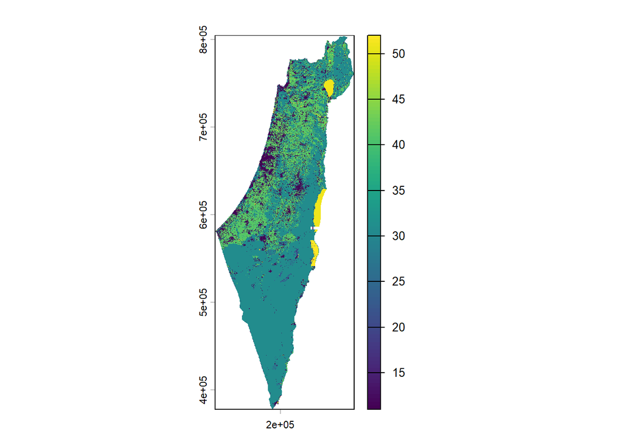

```r
# Land use data:
land.use <- rast(here("data/GIS/LC_Madad_MigvanB_21v1.tif")) # see the ReadMe file to see where this file is
plot(land.use) # seems ok
```

```r
land.use.legend <- read_excel(here("data/GIS/Categories4LC2020.xlsx"))

# Settlements data:
settlements <- st_read(here("data/GIS/SETL_bental_2021.shp")) # To calculate distance to nearest settlement
```

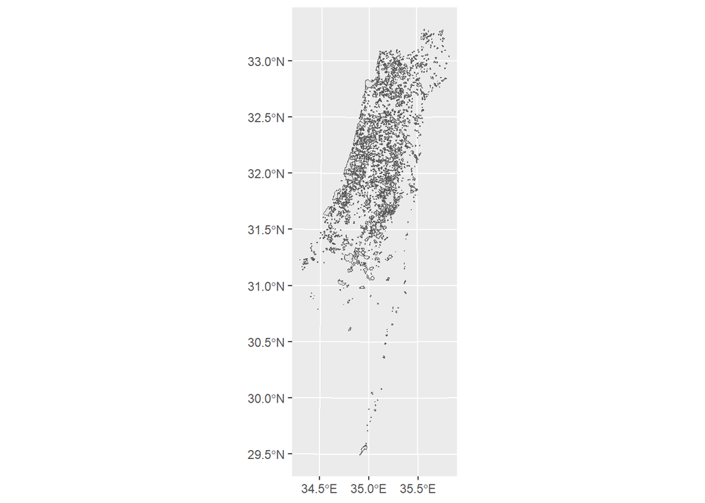

```r
ggplot() + geom_sf(data = settlements) # seems ok
```

```r
army.bases <- st_read(here("data/GIS/Army_camps_Harel_Dan/Fenced_15_11.shp")) # To calculate distance to nearest army base
```

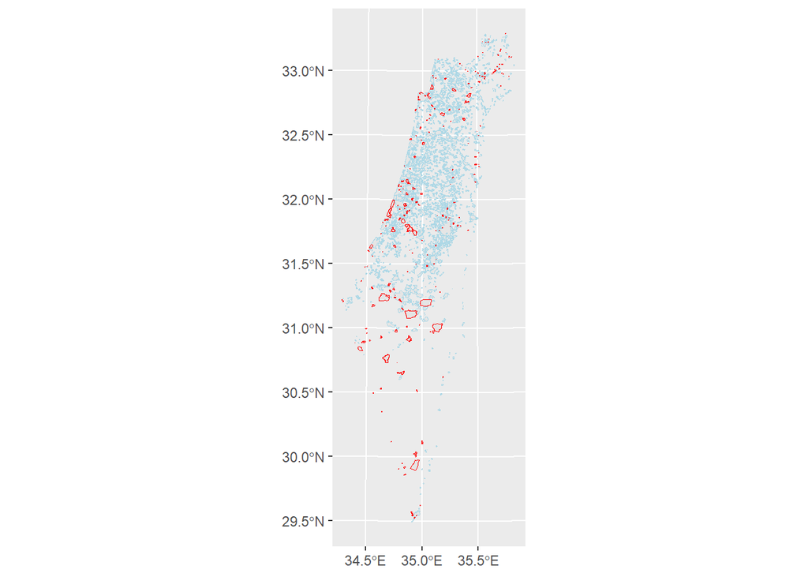

```r
ggplot() + geom_sf(data = settlements, color = "lightblue") + geom_sf(data = army.bases, color = "red") # seems ok
```